# Analyse Biological Data

Gerard Temprano Sagrera

```r
bio <- read.xlsx("C://Users/Gerard/Desktop/AAA/RNAseq/20221115_Datos Pacientes.xlsx")
bio <- bio[2:nrow(bio),]
bio$SEXO <- ifelse(bio$SEXO == 1, "Man","Woman")
```

```r
cases <- bio[bio$Status == "Case",]
controls <- bio[bio$Status == "Control",]
```

```r
cases2 <- cases[,7:ncol(cases)]
```

```r
#cases2[rowSums(is.na(cases2)) > 6,]
```

```r
#colSums(is.na(bio))
```

1. Only sample, status, sex and age have no NAs.
2. Cases only: Type, Symptomatic, Height, Weight, PAD, Other Aneurysm, Aortic Diameter, Leucocytes, Neutrophiles, Limphocytes, Monocytes, Platalets, Hb, RDW.
3. Controls only: Pathology.

Which column would be word to try to complete?

## Correlation study:

### All:

```r
# Select columns:
bio2 <- bio[,2:ncol(bio)]
bio2 <- bio2[,c("Status","SEXO","age","TIPOANEURISMA","symptomatic","Height_cm","Weight_Kg","Smoking","other_aneurysm",
                "aortc_diameter_mm")]

# Transform to numeric:
bio2$Status <- as.numeric(as.factor(bio2$Status))
bio2$SEXO <- as.numeric(as.factor(bio2$SEXO))

# Remove pathology:
bio2 <- bio2[ ,!names(bio2) %in% c("Pathology")]

bio2 <- as.data.frame(lapply(bio2, as.numeric))
```

```r
M <- cor(bio2, use = "pairwise.complete.obs")
testRes <- cor.mtest(bio2, conf.level = 0.95)

M[is.na(M)] <- 0
testRes$p[is.na(testRes$p)] <- 1

pdf(file = "C://Users/Gerard/Desktop/AAA/RNAseq/GitHub/Correaltion_Plot_All.pdf")
corrplot(M, p.mat = testRes$p, sig.level = 0.05, type = "lower", insig = "blank")
dev.off()
```

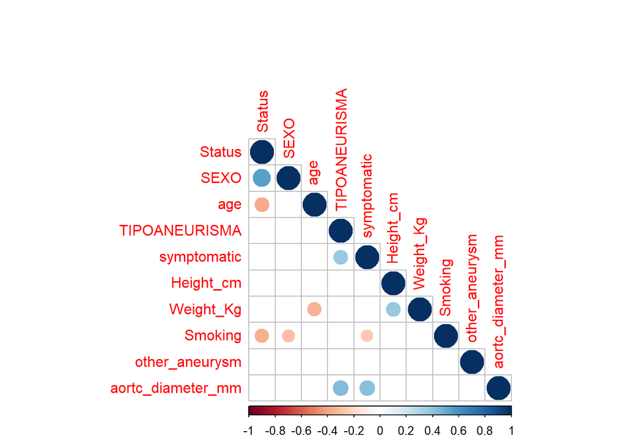

```r
corrplot(M, p.mat = testRes$p, sig.level = 0.05, type = "lower", insig = "blank")
```

- Type of aneurysm, height, weight, other aneurysm and size are only available for cases.
- Status with Sex: There are more male among cases.

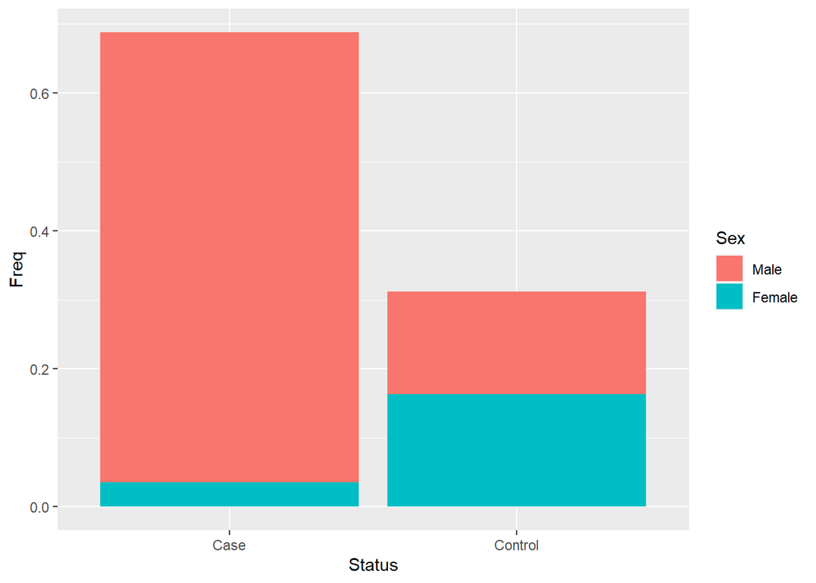

```r
tab <- as.data.frame(prop.table(table(bio2$Status, bio2$SEXO)))

ggplot(tab, aes(x = Var1, y = Freq, fill=Var2)) + geom_col() + labs(x = "Status", fill = "Sex") +
  scale_x_discrete(breaks = c(1,2), labels = c("Case","Control")) +
  scale_fill_discrete(breaks = c(1,2), labels = c("Male","Female"))
```

- Status with Age: Cases are older.

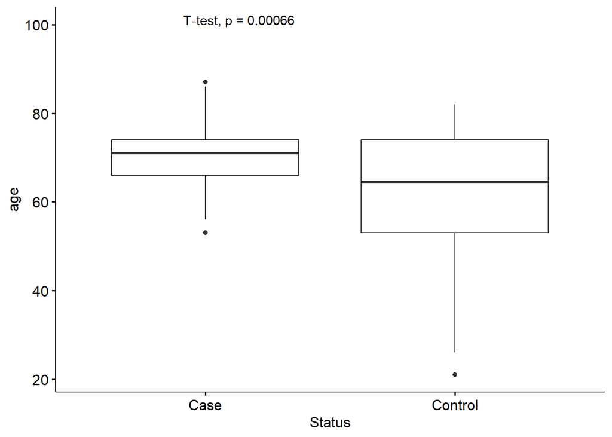

```r
ggboxplot(bio2, x = "Status", y = "age") +
  geom_boxplot() +
  stat_compare_means(method = "t.test", label.y = 100) +
  scale_x_discrete(breaks = c(1,2), labels = c("Case","Control"))
```

- Status with Smoking: There are less smokers in controls.

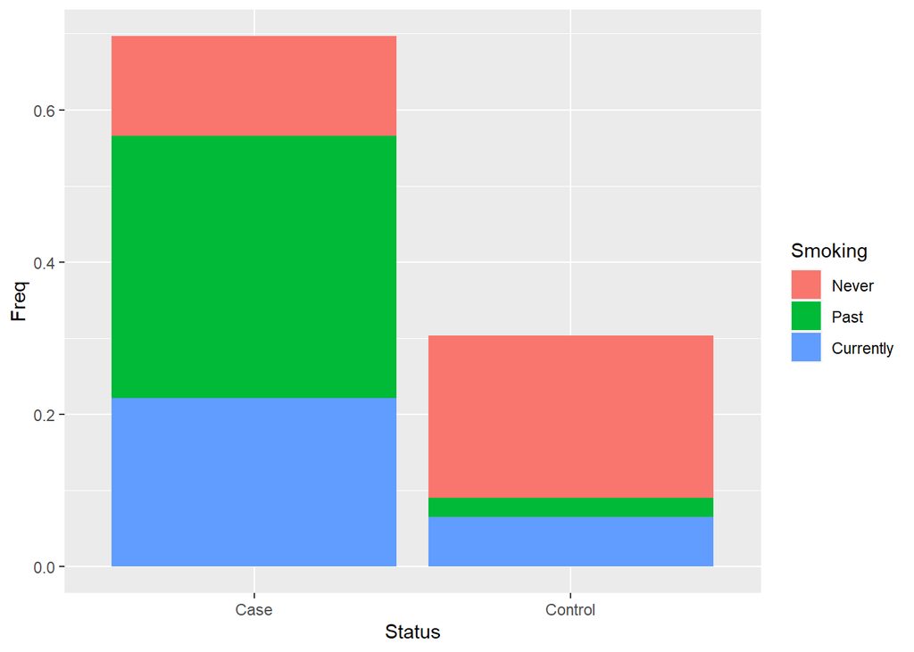

```r
tab <- as.data.frame(prop.table(table(bio2$Status, bio2$Smoking)))

ggplot(tab, aes(x = Var1, y = Freq, fill=Var2)) + geom_col() + labs(x = "Status", fill = "Smoking") +
  scale_x_discrete(breaks = c("1","2"), labels = c("Case","Control")) +
  scale_fill_discrete(breaks = c(0,1,2), labels = c("Never","Past","Currently"))
```

- Sex with Smoking: There are more smokers among men (There are more cases in men).

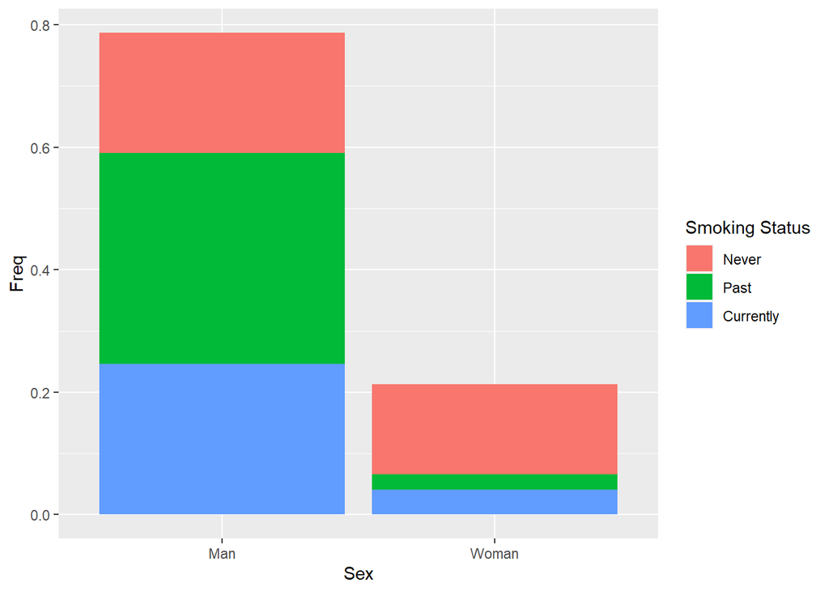

```r
tab <- as.data.frame(prop.table(table(bio2$SEXO, bio2$Smoking)))

ggplot(tab, aes(x = Var1, y = Freq, fill=Var2)) + geom_col() + labs(x = "Sex", fill = "Smoking Status") +
  scale_x_discrete(breaks = c("1","2"), labels = c("Man","Woman")) +
  scale_fill_discrete(breaks = c("0","1","2"), labels = c("Never","Past","Currently"))
```

- Age with Weight: Weight reduced with age.

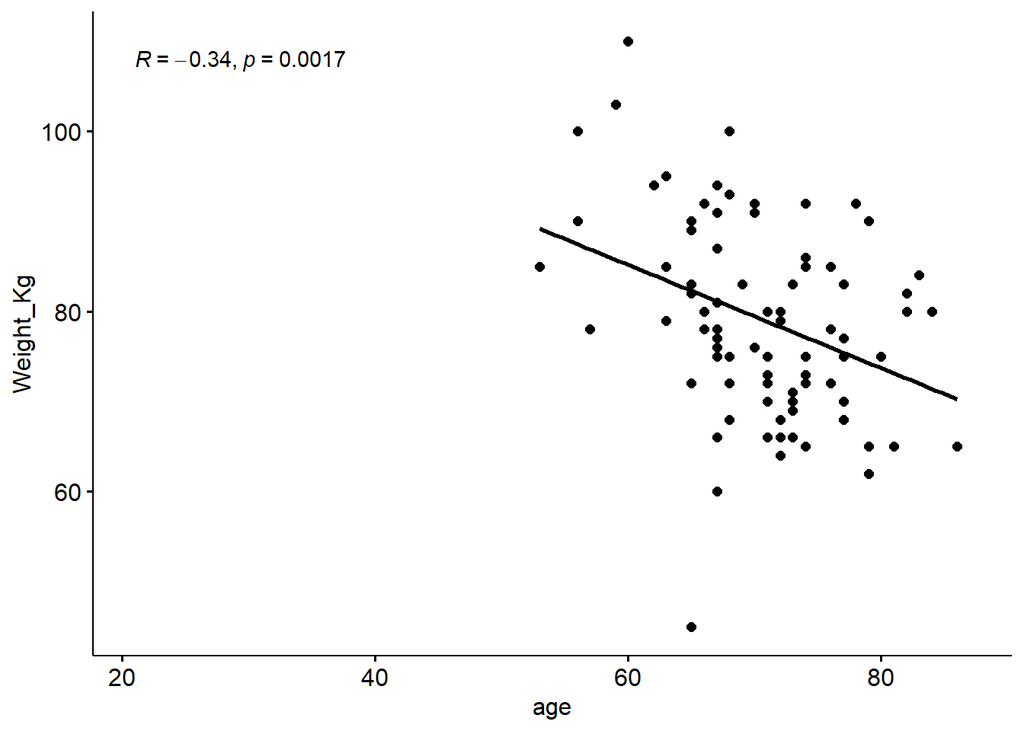

```r
ggscatter(bio2, x = "age", y = "Weight_Kg",
          add = "reg.line") +
  stat_cor(method = "pearson")
```

[figure not shown]

```r
tab <- as.data.frame(prop.table(table(bio2$TIPOANEURISMA, bio2$symptomatic)))

ggplot(tab, aes(x = Var1, y = Freq, fill=Var2)) + geom_col() + labs(x = "Type", fill = "Symptoms") +
  scale_x_discrete(breaks = c("1","2"), labels = c("Atherosclerotic","Inflammatory")) +
  scale_fill_discrete(breaks = c("0","1"), labels = c("Yes", "No"))
```

- Type with Aortic Diameter: Inflammatory aneurysms have bigger diameters.

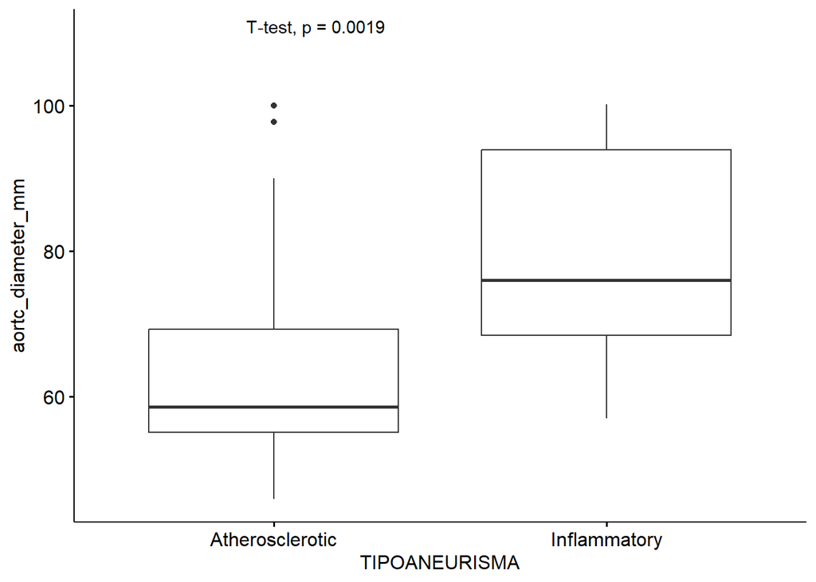

```r
ggboxplot(subset(bio2, !is.na(TIPOANEURISMA)), x = "TIPOANEURISMA", y = "aortc_diameter_mm") +
  geom_boxplot() +
  stat_compare_means(method = "t.test", label.y = 110) +
  scale_x_discrete(breaks = c(1,2), labels = c("Atherosclerotic","Inflammatory"))
```

- Symptoms with Smoking:

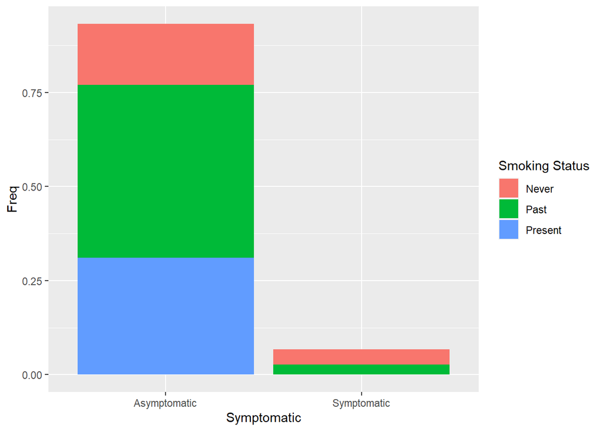

```r
tab <- as.data.frame(prop.table(table(bio2$symptomatic, bio2$Smoking)))

ggplot(tab, aes(x = Var1, y = Freq, fill=Var2)) + geom_col() + labs(x = "Symptomatic", fill = "Smoking Status") +
  scale_x_discrete(breaks = c("0","1"), labels = c("Asymptomatic","Symptomatic")) +
  scale_fill_discrete(breaks = c("0","1","2"),labels = c("Never", "Past", "Present"))
```

- Symptoms with Diameter: Symptomatic aneurysms are bigger.

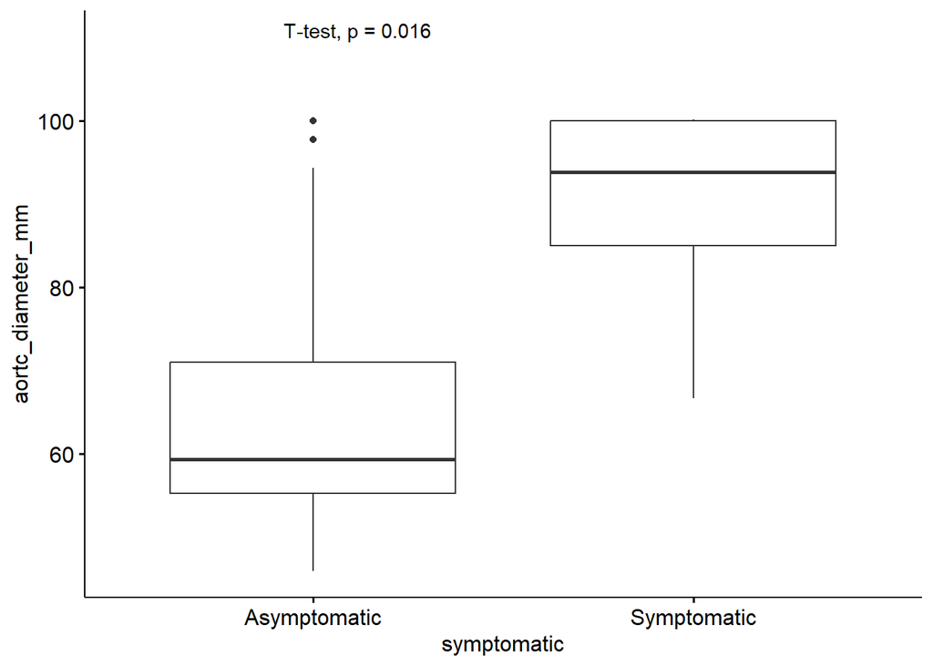

```r
ggboxplot(subset(bio2, !is.na(symptomatic)), x = "symptomatic", y = "aortc_diameter_mm") +
  geom_boxplot() +
  stat_compare_means(method = "t.test", label.y = 110) +
  scale_x_discrete(breaks = c(0,1), labels = c("Asymptomatic","Symptomatic"))
```

- Weight with Height.

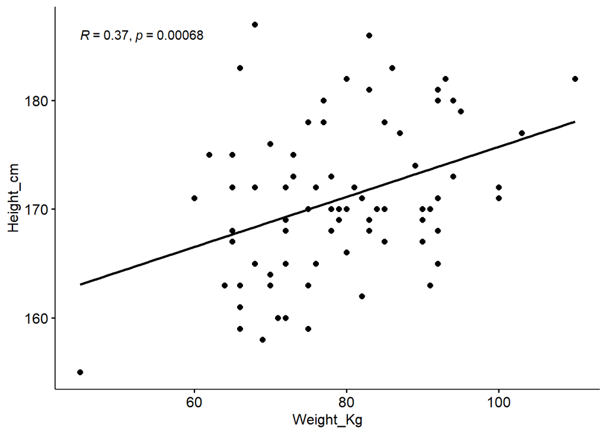

```r
ggscatter(bio2, x = "Weight_Kg", y = "Height_cm",
          add = "reg.line") +
  stat_cor(method = "pearson")
```

## Cases:

```r
cases <- bio2[1:97,]
cases <- cases[,2:ncol(cases)]
```

```r
M <- cor(cases, use = "pairwise.complete.obs")
testRes <- cor.mtest(cases, conf.level = 0.95)

M[is.na(M)] <- 0
testRes$p[is.na(testRes$p)] <- 1

pdf(file = "C://Users/Gerard/Desktop/AAA/RNAseq/GitHub/Correaltion_Plot_Cases.pdf")
corrplot(M, p.mat = testRes$p, sig.level = 0.05, type = "lower", insig = "blank")
dev.off()
```

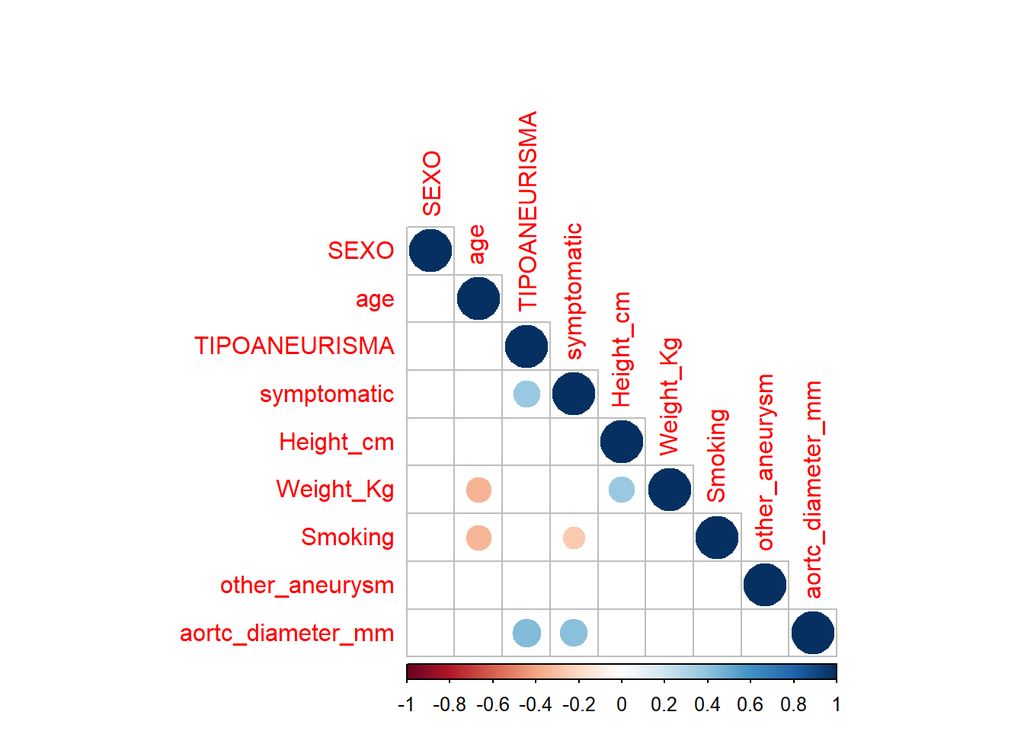

```r
corrplot(M, p.mat = testRes$p, sig.level = 0.05, type = "lower", insig = "blank")
```

- Age with Weight: Weight reduces with age.

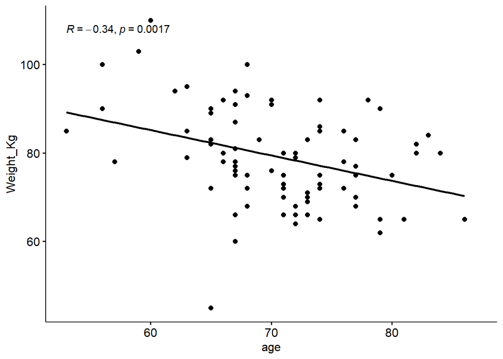

```r
ggscatter(cases, x = "age", y = "Weight_Kg",
          add = "reg.line") +
  stat_cor(method = "pearson")
```

- Age with Smoking: Currently smokers are younger.

[output not shown]

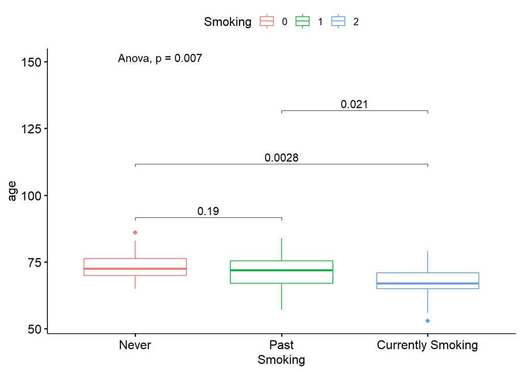

```r
my_comparisons <- list( c("0","1"), c("0", "2"), c("1", "2") )

ggboxplot(subset(cases, !is.na(Smoking)), x = "Smoking", y = "age", color = "Smoking") +
  stat_compare_means(comparisons = my_comparisons, label.y = c(90, 110, 130), method = "t.test") +
  stat_compare_means(label.y = c(150), method = "anova") +
  scale_x_discrete(breaks = c("0","1","2"), labels = c("Never","Past","Currently Smoking"))
```

[figure not shown]

```r
tab <- as.data.frame(prop.table(table(cases$symptomatic, cases$TIPOANEURISMA)))

ggplot(tab, aes(x = Var2, y = Freq, fill=Var1)) + geom_col() + labs(fill = "Symptomatic", x = "Type") +
  scale_fill_discrete(labels = c("Yes", "No")) +
  scale_x_discrete(labels = c("Atherosclerotic","Inflammatory"))
```

- Type of Aneurysm with Diameter: Inflammatory aneurysms are bigger.

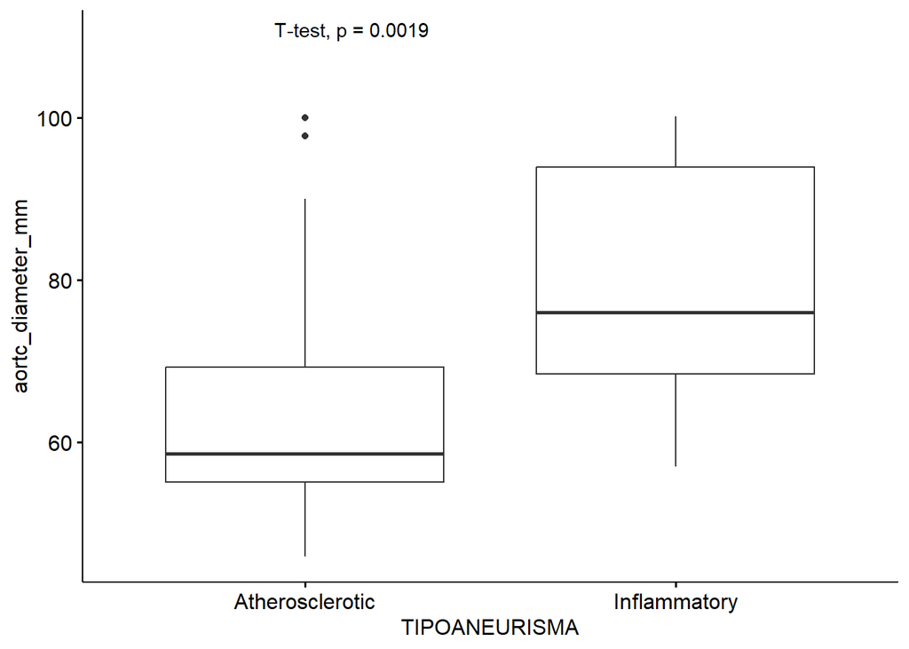

```r
ggboxplot(subset(cases, !is.na(TIPOANEURISMA)), x = "TIPOANEURISMA", y = "aortc_diameter_mm") +
  geom_boxplot() +
  stat_compare_means(method = "t.test", label.y = 110) +
  scale_x_discrete(breaks = c(1,2), labels = c("Atherosclerotic","Inflammatory"))
```

- Symptoms with Smoking:

[figure not shown]

```r
tab <- as.data.frame(prop.table(table(cases$symptomatic, cases$Smoking)))

ggplot(tab, aes(x = Var1, y = Freq, fill=Var2)) + geom_col() + labs(x = "Smoking Status", fill = "Symptoms") +
  scale_x_discrete(breaks = c("0","1"), labels = c("Asymptomatic","Symptomatic")) +
  scale_fill_discrete(breaks = c("0","1","2"),labels = c("Never", "Past", "Present"))
```

- Symptoms with Diameter: Symptomatic aneurysms are bigger.

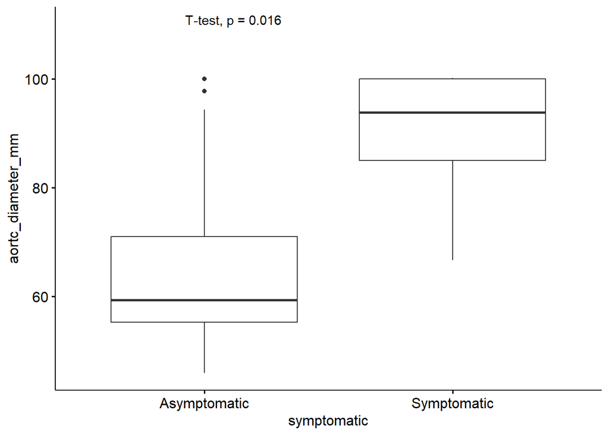

```r
ggboxplot(subset(cases, !is.na(symptomatic)), x = "symptomatic", y = "aortc_diameter_mm") +
  geom_boxplot() +
  stat_compare_means(method = "t.test", label.y = 110) +
  scale_x_discrete(breaks = c(0,1), labels = c("Asymptomatic","Symptomatic"))
```

- Height with Weight.

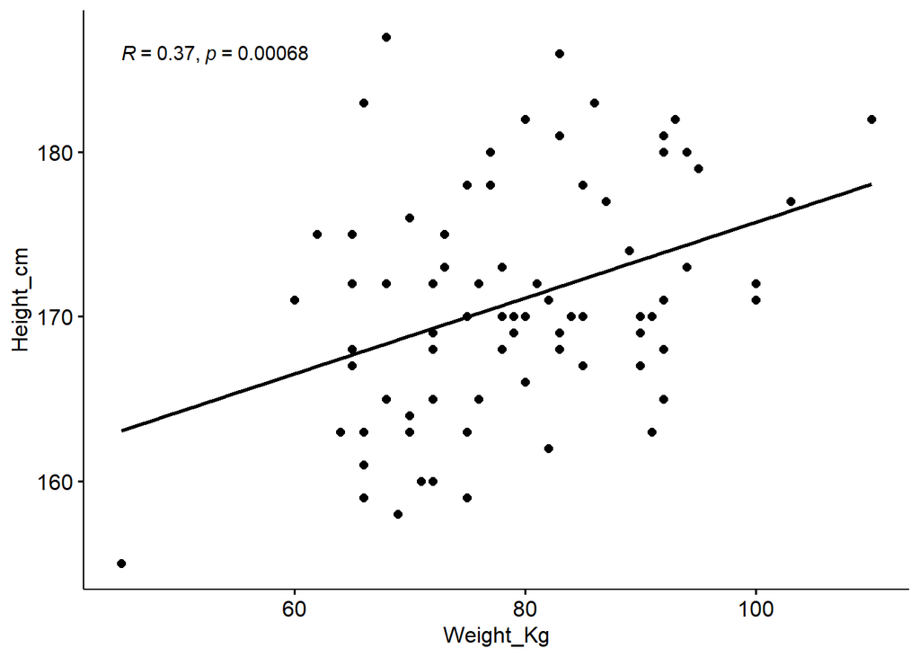

```r
ggscatter(cases, x = "Weight_Kg", y = "Height_cm",
          add = "reg.line") +
  stat_cor(method = "pearson")
```

## Controls:

```r
controls <- bio2[98:nrow(bio2),]
controls <- controls[,2:ncol(controls)]
controls <- controls[,c("SEXO","age","Smoking")]
```

```r
M <- cor(controls, use = "pairwise.complete.obs")
testRes <- cor.mtest(controls, conf.level = 0.95)

M[is.na(M)] <- 0
testRes$p[is.na(testRes$p)] <- 1

pdf(file = "C://Users/Gerard/Desktop/AAA/RNAseq/GitHub/Correaltion_Plot_Controls.pdf")
corrplot(M, p.mat = testRes$p, sig.level = 0.05, type = "lower", insig = "blank")
dev.off()
```

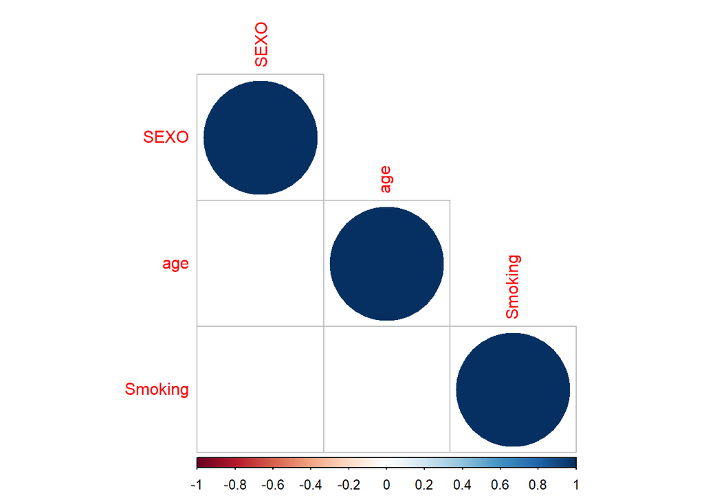

```r
corrplot(M, p.mat = testRes$p, sig.level = 0.05, type = "lower", insig = "blank")
```

### Aneurysm type (Cases only):

```r
table(cases$TIPOANEURISMA, useNA = "always")
```

```
##
##    1    2 <NA>
##   54   16   27
```

Among cases, there are 27 NAs

### Pathology (Controls only):

```r
#table(controls$Pathology, useNA = "always")
```

### Symptomatic (Cases only):

```r
table(cases$symptomatic, useNA = "always")
```

```
##
##    0    1 <NA>
##   69    5   23
```

There are only 5 sympromatic aneurysms among cases.

Controls don’t have information about Height or Weight.

### Height (Cases only):

```r
sum(is.na(cases$Height_cm))
```

```
## [1] 17
```

```r
17/nrow(cases)*100
```

```
## [1] 17.52577
```

```r
range(cases$Height_cm, na.rm = T)
```

```
## [1] 155 187
```

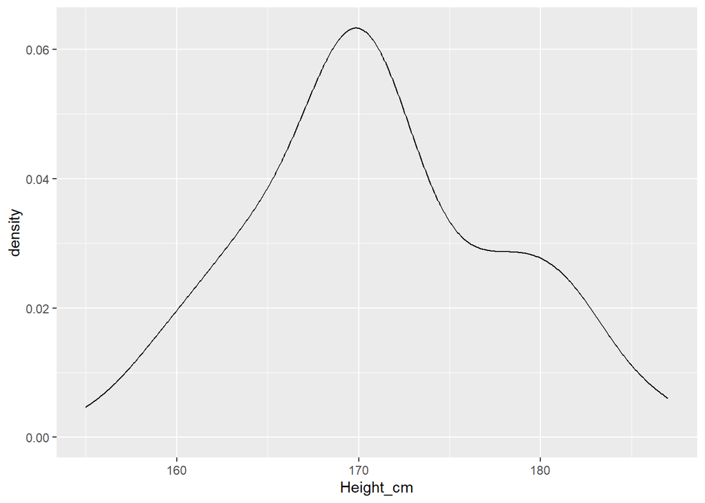

```r
ggplot(cases, aes(Height_cm)) + geom_density()
```

There are 17 cases with no Height information.

### Weight (Cases only):

```r
sum(is.na(cases$Weight_Kg))
```

```
## [1] 16
```

```r
range(cases$Weight_Kg, na.rm = T)
```

```
## [1]  45 110
```

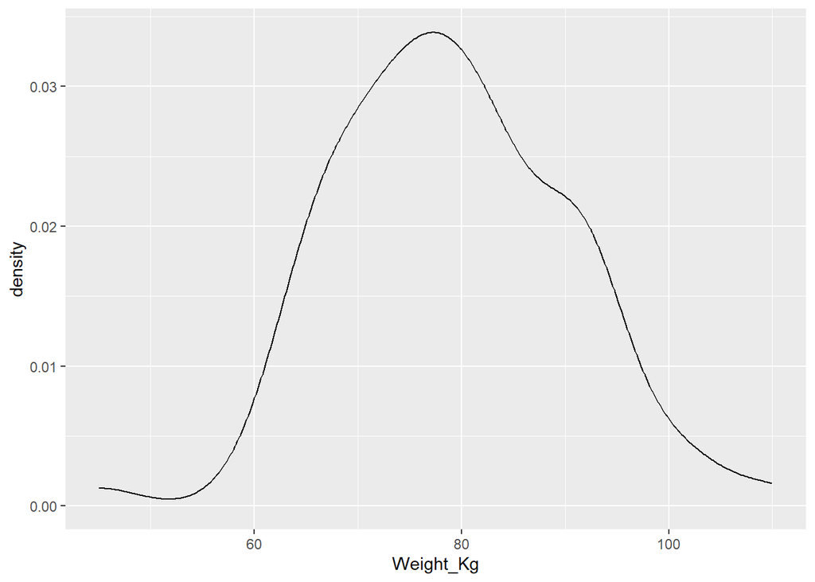

```r
ggplot(cases, aes(Weight_Kg)) + geom_density()
```

There are 16 cases with no Weight information.

### Smoking:

```r
table(cases$Smoking, useNA = "always")
```

```
##
##    0    1    2 <NA>
##   16   42   27   12
```

There are 12 cases with no smoking information.

```r
table(controls$Smoking, useNA = "always")
```

```
##
##    0    1    2 <NA>
##   26    3    8    7
```

There are 7 controls with no smoking information.

## Diseases

### Hypertension:

```r
table(bio$hypertension, bio$Status, useNA = "always")
```

```
##
##        Case Control <NA>
##   0      30      22    0
##   1      55      15    0
##   <NA>   12       7    0
```

There are 19 NAs.

### Dyslipedmia:

```r
table(bio$dyslipidemia, bio$Status, useNA = "always")
```

```
##
##        Case Control <NA>
##   0      39      27    0
##   1      46      10    0
##   <NA>   12       7    0
```

There are 19 NAs.

### Diabetes mellitus:

```r
table(bio$diabetes.mellitus, bio$Status, useNA = "always")
```

```
##
##        Case Control <NA>
##   0      73      32    0
##   1      12       5    0
##   <NA>   12       7    0
```

There are 19 NAs.

```r
if(identical(bio[is.na(bio$hypertension),]$Muestra, bio[is.na(bio$dyslipidemia),]$Muestra) == TRUE & identical(bio[is.na(bio$dyslipidemia),]$Muestra, bio[is.na(bio$diabetes.mellitus),]$Muestra) == TRUE){
  print("The 19 samples with NAs are the same for Hypertension, Dyslipedmia and Diabetes Mellitus")}
```

```
## [1] "The 19 samples with NAs are the same for Hypertension, Dyslipedmia and Diabetes Mellitus"
```

### PAD (only Cases):

```r
table(cases$PAD, useNA = "always")
```

```
##
## <NA>
##    0
```

### Other Aneurysm (only cases):

```r
table(cases$other_aneurysm, useNA = "always")
```

```
##
##    0    1 <NA>
##   60   25   12
```

There are 12 NAs among cases.

### CVE:

```r
table(bio$CVE, bio$Status, useNA = "always")
```

```
##
##        Case Control <NA>
##   0      47      34    0
##   1      36       3    0
##   <NA>   14       7    0
```

There are 21 NAs.

### CVD:

```r
table(bio$CVD, bio$Status, useNA = "always")
```

```
##
##        Case Control <NA>
##   0      69      28    0
##   0?      0       8    0
##   1      16       1    0
##   <NA>   12       7    0
```

### COPD:

```r
table(bio$COPD, bio$Status, useNA = "always")
```

```
##
##        Case Control <NA>
##   0      70      36    0
##   1      15       1    0
##   <NA>   12       7    0
```

### Kidney Disease:

```r
table(bio$kidney_disease, bio$Status, useNA = "always")
```

```
##
##        Case Control <NA>
##   0      68      35    0
##   1      17       2    0
##   <NA>   12       7    0
```

### Aortic Diameter:

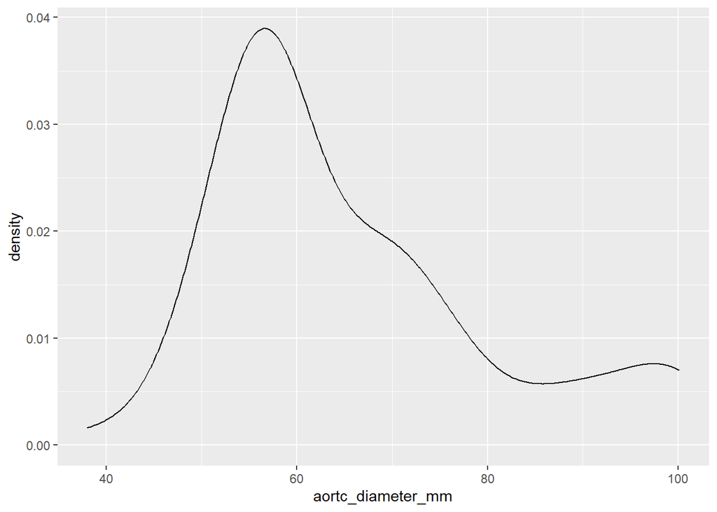

```r
ggplot(cases, aes(aortc_diameter_mm)) + geom_density()
```

There are 12 cases with NAs diameter.

```r
nrow(cases[cases$aortc_diameter_mm > 55,])
```

```
## [1] 75
```

```r
nrow(cases[cases$aortc_diameter_mm < 55,])
```

```
## [1] 27
```

```r
range(cases$aortc_diameter_mm, na.rm = T)
```

```
## [1]  38.00 100.12
```